# An Introduction to Version Control

10/25/2019

## What is version control?

- A way to manage changes to documents and data
- A backup system for important files
- A collaborative tool

[figure not shown]

## Who should use version control?

- Anyone working with numerical data and scripts that change through time

[figure not shown]

## Who should use version control?

- Anyone working with numerical data and scripts that change through time

[figure not shown]

## Who should use version control?

- Anyone working with numerical data and scripts that change through time

[figure not shown]

## How does version control work?

- There is only ever a single version of a file active at a time

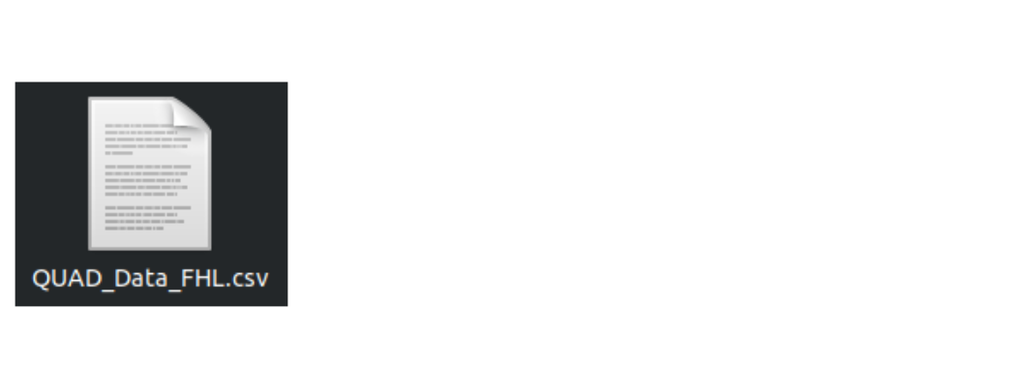

## How does version control work?

- There is only ever a single version of a file active at a time
- Previous versions are stored in ‘change logs’
- Updated versions of files are saved and then ‘committed’ via version control software

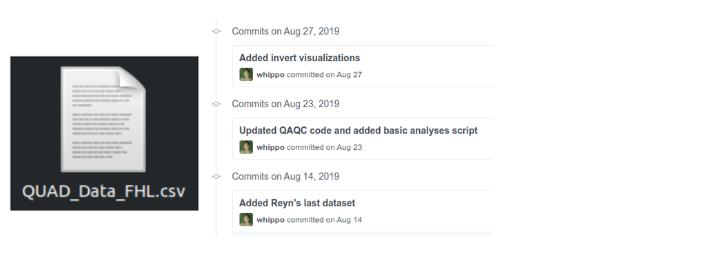

## How does version control work?

- There is only ever a single version of a file active at a time
- Previous versions are stored in ‘change logs’
- Updated versions of files are saved and then ‘committed’ via version control software
- These versions are saved locally and/or ‘pushed/pulled’ to/from the cloud

[figure not shown]

## Considerations for version control

- Works best for text or numerical files (.txt, .csv, .R)
- Requires initial setup and software
- Can be scary!

## What do you need to use version control?

- A computer (duh)
- Version control software (Git, Subversion)
- An interface (RStudio, GitKraken)

## What does version control look like?

- Create repository (‘repo’) that will hold files
- Make changes to your document and save
- ‘Commit’ your changes via Git interface
- ‘Push’ your changes to the cloud

## Resources

- Student software package (GitHub, GitKraken) https://education.github.com/pack
- GitKraken Cheatsheet https://www.gitkraken.com/resources/gitkraken-github-cheat-sheet
- GitKraken Resources https://www.gitkraken.com/student-resources

[figure not shown]